# Relationship between Geopotential Heigh & Flood Magnitude

Group 7

March 6, 2016

## Abstraction

This section explores the relationship between Geopotential Heigh and Flood Magnitude by two major datasets. This first one is the “NOAA_Daily_phi_500mb.nc”, which provides the geopotential heigh values and the second one is the “GlobalFloodsRecord.xls”, which provides different kinds of flood data. In addition, we focous on both dataset in 2012 to 2013 as well as 2014 to 2015 within the region of the United States.

## Methology

scatter plot is utilized to glance at corresponding geopotential heigh values and flood magnitude. Besides, a simple linear regression models is used to determine the relationship between the two variables: $floodMagnitude = \beta_0 + \beta_1 * geopotentialHeigh$

## Data

```
##   phi_value1213 magnitude1213
## 1      5730.727           5.9
## 2      5824.222           6.3
## 3      5823.667           5.7
## 4      5807.500           6.4
## 5      5807.500           6.1
## 6      5735.500           5.4
```

Below are the data values from 2014 to 2015. Same as above, the corresponding geopotential heigh value is takeing as mean during that period of time

```
##   phi_value1415 magnitude1415
## 1      5759.889           6.6
## 2      5792.154           6.2
## 3      5874.000           5.9
## 4      5870.500           5.4
## 5      5803.000           5.7
## 6      5843.536           8.0
```

## Result

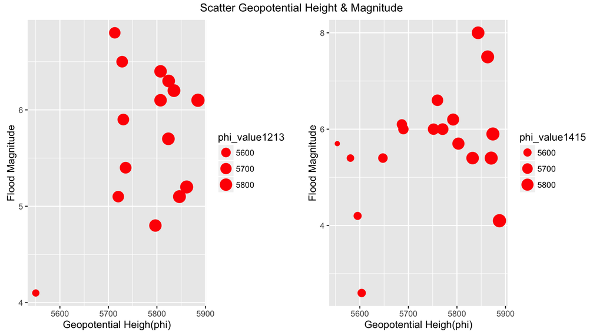

```r
# Visualization with the Data
# Bubble plot for phi from 2012 to 2013
bubble.1213 <- ggplot(phi_magni1213, aes(phi_value1213, magnitude1213, size = phi_value1213))
bubble.1213 <- bubble.1213 + geom_point(colour = "red") + scale_size(range = c(3, 6)) + xlab("Geopotential Heigh(phi)") + ylab("Flood Magnitude")
# Bubble plot for phi from 2014 to 2015
bubble.1415 <- ggplot(phi_magni1415, aes(phi_value1415, magnitude1415, size = phi_value1415))
bubble.1415 <- bubble.1415 + geom_point(colour = "red") + scale_size(range = c(2, 6)) + xlab("Geopotential Heigh(phi)") + ylab("Flood Magnitude")
# Display 2 graphics in a single window
grid.arrange(bubble.1213, bubble.1415, ncol = 2, top = "Scatter Geopotential Height & Magnitude")
```

The above graphics display the relationship between geopotential heigh and flood magnitude in an Euclidean space, where the x axis represents geopotential heigh(phi) value and the y axis preresents the flood magnitude value. The size of the bubble also indicate how large the corresponding phi value is.

The correlation between these variables are also included below

geopotential heigh and flood magnitude correlation from 2012-2013:

```r
# Explore the correlation between phi & magnitude
cor.phi.mag1213 <- cor(phi_magni1213$phi_value1213, phi_magni1213$magnitude1213)
cor.phi.mag1213
```

```
## [1] 0.3698957
```

geopotential heigh and flood magnitude correlation from 2014-2015:

```r
cor.phi.mag1415 <- cor(phi_magni1415$phi_value1415, phi_magni1415$magnitude1415)
cor.phi.mag1415
```

```
## [1] 0.4008081
```

finally a simple linear regression model is being appied to the dataset.

geopotential heigh and flood magnitude regression from 2012-2013:

```r
###########################################
# Fitting a linear regression for year 12 & 13 data
lm.phi.mag1213 <- lm(magnitude1213 ~ phi_value1213, data = phi_magni1213)
summary(lm.phi.mag1213)
```

```
##
## Call:
## lm(formula = magnitude1213 ~ phi_value1213, data = phi_magni1213)
##
## Residuals:
##      Min       1Q   Median       3Q      Max
## -0.97609 -0.60638  0.03615  0.38745  1.29840
##
## Coefficients:
##                 Estimate Std. Error t value Pr(>|t|)
## (Intercept)   -13.227083  13.195664  -1.002    0.334
## phi_value1213   0.003278   0.002284   1.435    0.175
##
## Residual standard error: 0.7168 on 13 degrees of freedom
## Multiple R-squared:  0.1368, Adjusted R-squared:  0.07042
## F-statistic: 2.061 on 1 and 13 DF,  p-value: 0.1748
```

```r
sp1213 <- ggplot(phi_magni1213, aes(phi_value1213, magnitude1213))
sp1213 <- sp1213 + geom_point(colour = "red") + stat_smooth(method = lm, level = 0.99) + xlab("Geopotential Heigh(phi)") + ylab("Flood Magnitude")
```

geopotential heigh and flood magnitude regression from 2014-2015:

```r
# Fitting a linear regression for year 14 & 15 data
lm.phi.mag1415 <- lm(magnitude1415 ~ phi_value1415, data = phi_magni1415)
summary(lm.phi.mag1415)
```

```
##
## Call:
## lm(formula = magnitude1415 ~ phi_value1415, data = phi_magni1415)
##
## Residuals:
##     Min      1Q  Median      3Q     Max
## -2.4670 -0.5770  0.2512  0.6461  1.8941
##
## Coefficients:
##                 Estimate Std. Error t value Pr(>|t|)
## (Intercept)   -19.224277  14.232740  -1.351   0.1956
## phi_value1415   0.004335   0.002477   1.750   0.0993 .
## ---
## Signif. codes:  0 '***' 0.001 '**' 0.01 '*' 0.05 '.' 0.1 ' ' 1
##
## Residual standard error: 1.141 on 16 degrees of freedom
## Multiple R-squared:  0.1606, Adjusted R-squared:  0.1082
## F-statistic: 3.062 on 1 and 16 DF,  p-value: 0.09928
```

```r
sp1415 <- ggplot(phi_magni1415, aes(phi_value1415, magnitude1415))
sp1415 <- sp1415 + geom_point(colour = "red") + stat_smooth(method = lm, level = 0.99) + xlab("Geopotential Heigh(phi)") + ylab("Flood Magnitude")
```

visualize the result:

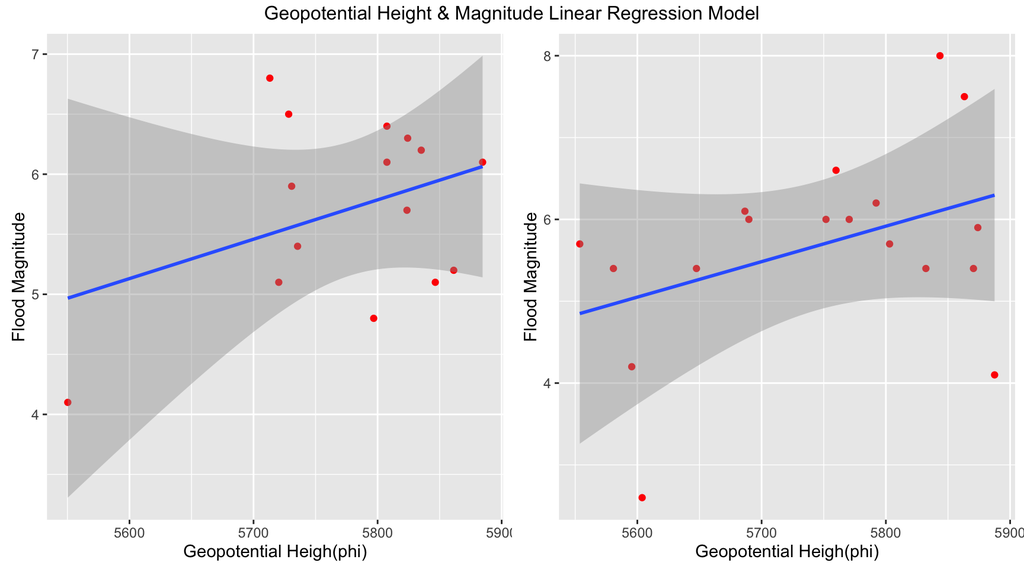

```r
# Display 2 graphics in a single window
grid.arrange(sp1213, sp1415, ncol = 2, top = "Geopotential Height & Magnitude Linear Regression Model")
```

Both the shaped areas represent the 99% confident level in the regression model.

## Conclusion

From the above result, we can not find a statiscal significant relationship between geopotential heigh and flood magnitude in the Uinted States from 2012 to 2013 and 2014 to 2015 data.